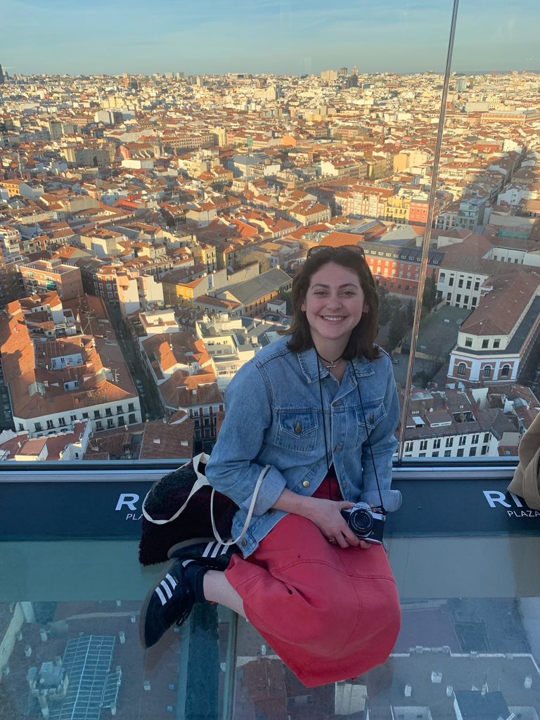

# Natalia Sifnugel

## Bio

Hello! My name is Natalia and I’m a Master of Public Health student at Johns Hopkins. I grew up in Boston and have also lived in New Orleans and Madrid. For several years, I worked as a research assistant in neuroscience and immunology labs, uncovering the biological mechanisms of psychiatric disorders and finding ways to enhance the immune system’s ability to fight cancer. At Hopkins, I am studying Epidemiology and Biostatistics and in my career, I want to use these skills to better understand health outcomes in vulnerable populations. Leveraging my research training, I want to reduce health disparities, particularly in mental health and inflammatory disorders.

Along with science and public health, I am also interested in travel and photography. While living in Madrid, I visited over 20 new places. I always brought my film camera with me to capture interesting architecture and exciting memories. Since moving to Baltimore, I have been expanding my creative outlets and am learning how to knit!

## Education

**Johns Hopkins Bloomberg School of Public Health** | Baltimore, MD

Master of Public Health | July 2023 - May 2024

**Tulane University** | New Orleans, LA

Bachelor of Science in Neuroscience | August 2016 - May 2020

## Experience

**CEIP Rosa Luxemburgo** English Language Teaching Assistant| October 2022 - April 2023

**Harvard Medical School, Laboratory of Dr. Arlene H. Sharpe** | Research Assistant II | September 2020 - August 2022

**Tulane Brain Institute, Laboratory of Dr. Jonathan P. Fadok** | Undergraduate Research Assistant | January 2018 - May 2020